# Week 7

# 1 CCAO

[Chihacknight](https://youtu.be/h0pwAr-WYxI)

## 1.1 Figure 10.1

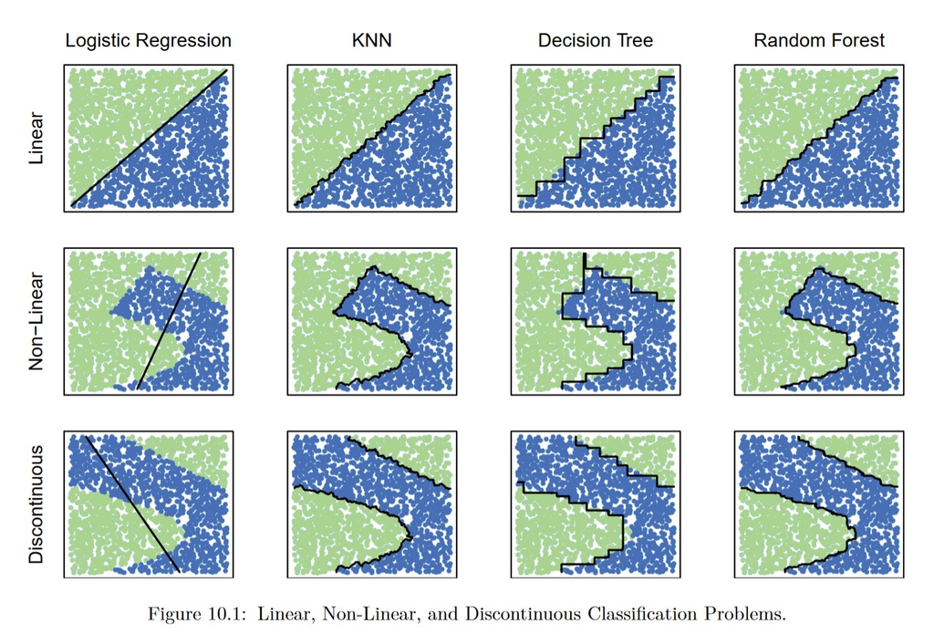

An overview of various ML algorithms in linear/non-linear/and discontinuous parameter spaces.

Note that the textbook uses `caret`, while this is a useful pacakge we will continue to use `tidymodels`. Be sure to review the discussion of cross validation and hyperparameter tuning in the textbook.

# 2 KNN

1. Calculate distance
2. Vote (either proportions to probabilities or majority voting to classification)

Notes:

- Key to standardize units for calculating distances
- Can create categorical bins with distance of ‘1’ between bins (such as 18-24, 25-29, etc)
- Tuning is very important. Should you look at the 5 closest points or 50?

Takeaway:

“In practice, k-NNs are best suited when datasets are smaller and contain fewer variables. They are also well suited when data is recorded along a grid (e.g., spatial, sound, imagery) and there is a lack of a theory of that guides how the inputs relate to the target or prediction.”

Recall unsupervised K-means clustering example from week 3. What is different in this case? (In this supervised example, we have labeled data and are trying to make class predictions based on input characteristics.)

# 3 Simple Trees/CART

Recall our previous discussion on decision trees.

Decision Trees are a recursive algorithm where samples are continuously evaluated to be ‘split’ until stopping conditions are reached.

1. Base Case: check if all values are too similar (or identical), if so terminate and you are at a leaf
2. Recursive Partitioning: if not at a base case, split into two children/nodes to maximize information gain/reduce impurity
3. Stopping Criteria/Pruning: nodes should not become too small, if they are stop

Note: likely to overfit the data, limitations on out of sample predictions (e.g. an outlier value which exceeds the highest value seen in your training data)

# 4 Random Forests

- bagging/bootstrapping: aggregating predictions from multiple models
- random subspace method: select a random subset of variables at each node of each tree

Goal is to force trees to be uncorrelated.

## 4.1 Key parameters

Variable Subsampling: fixed number of variables to use. Minimum Node Size: size of leaf nodes in each tree

The number of trees in the forest can also be tuned but this impacts ‘the stability of consensus rather than accuracy’

# 5 Cross Validation/Hyperparameter Optimization

Model Evaluation, Model Selection, and Algorithm Selection in Machine Learning

How do we select models and ‘tune’ hyperparameters?

Before we have talked about using testing and training datasets. This is a ‘two-way’ split of the data. For hyperparameter tuning, we can use a ‘three-way’ split into training, testing, and validation.

## 5.1 Three goals of Performance Estimation

1. We want to estimate the generalization accuracy, the predictive performance of a model on future (unseen) data.
2. We want to increase the predictive performance by tweaking the learning algorithm and selecting the best-performing model from a given hypothesis space.
3. We want to identify the machine learning algorithm that is best-suited for the problem at hand; thus, we want to compare different algorithms, selecting the best-performing one as well as the best-performing model from the algorithm’s hypothesis space.

k-fold cross validation.

# 6 10.4.4

*From Chapter 10*

In this DIY, we prototype a tree-based model to *predict* wages based on worker characteristics gathered from a widely used survey. *What can a wage model be used for?* Having an accurate prediction model can be used to evaluate if staff are under-valued in the market, which in turn can be used to pre-empt possible churn with pay increases. A wage model could help set expectations on employment costs, scoring new positions to support budgetary and human resources use cases.

**Data**. Drawing on the US Census Bureau’s 2016 American Community Survey (ACS), we constructed a training sample (`train`) and test sample (`test`) focused on California. Each sample randomly draws a set of $n=3000$ records, mainly to reduce the computational overhead for this exercise while preserving the patterns in the data.[^1] The data have been filtered to a subset of employed wage earners (`> $0 earned`) who are 18 years of age and older. Each sample contains the essential variables needed for predicting fair wages, namely experience, education, hours worked per week, among others:

- `id` is a unique identification number
- `wage` of the respondent in 2016.
- `exp` is the number of years of experience (approximated from age and education attainment)
- `schl` is the highest level of education attained.
- `wkhp` is the hours worked per week.
- `naics` is a NAICS code used to identify the industry in which the respondent is working.
- `soc` is a description for the Standard Occupation Code (SOC) used for job classification.
- `work.type`. Class of worker indicates whether a respondent works for government, for-profit business, etc.

```r
#Load data
load(url("https://github.com/DataScienceForPublicPolicy/diys/raw/main/data/wages.Rda"))
```

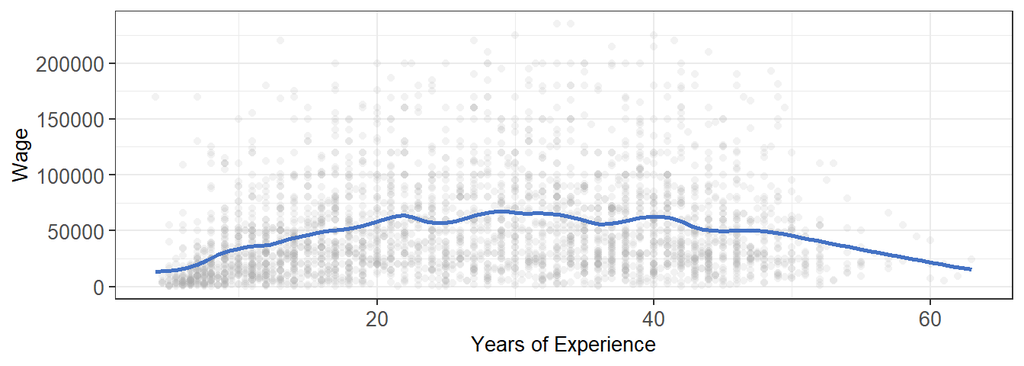

Wage by years of experience.

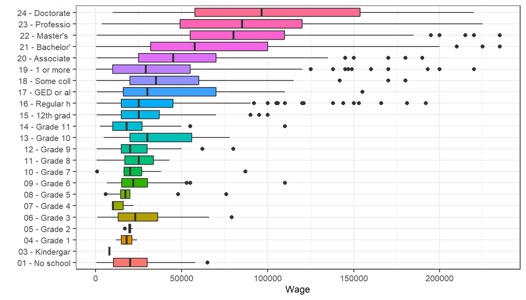

Wage by education attainment.

**Training**. When we train algorithms, we should take advantage of the interactions between type of job, industry, role among other factors to produce richer more accurate predictions and tree-based algorithms such as CART (`rpart` package) and Random Forest (`ranger` package) are perfect for this type of problem. But which tree-based algorithm would work best? The answer lies in a computer science tradition that pits two or more models against one another in a *horse race*. Through cross validation, we can compare Root Mean Squared Error (RMSE) that penalize larger errors in order to identify which algorithm is the all-around best.

```r
#Load packages
library(tidymodels)
```

A fair horse race places all algorithms on the same field under similar conditions. For setting up model comparisons, we train the algorithms in a five-fold cross validation design.[^2] As for the input variables, we could hand-select a set that we believe best represents wages at the risk of biasing the predictions. Alternatively, we “*toss in the kitchen sink*” in which all variables are included in all models, allowing the algorithm to identify the most statistically relevant variables.

```r
folds <- vfold_cv(train, v=5)

tree_recipe <- recipe(wage ~ exp + schl +
                wkhp + naics + soc + work.type, data=train) %>%
  step_unknown(all_nominal_predictors()) %>%
  step_dummy(all_nominal_predictors()) %>%
  step_dummy(all_factor())


tree_recipe %>% prep() %>% bake(train)

dt_mod <-
  decision_tree(cost_complexity = tune()) %>%
  set_mode('regression') %>%
  set_engine('rpart')

tree_grid <- grid_regular(cost_complexity(),
                          levels = 5)

dt_wf <-
  workflow() %>%
  add_model(dt_mod) %>%
  add_recipe(tree_recipe)
```

```r
tree_res <-
  dt_wf %>%
  tune_grid(
    resamples = folds,
    grid = tree_grid
    )


tree_res %>% collect_metrics()
```

Let’s take a look at the results captured. As the `cp` value falls to zero, the model becomes more complex and “soaks up” more of the patterns in the data, which in turn causes the error to fall sharply. It also becomes clear how sensitive CART performance is to tree complexity – if it is not complex enough, the model will produce underwhelming results that miss the mark. Overly complex trees, in contrast, produce noisy results. Finding the Goldilocks value of `cp` is of paramount importance.

```r
tree_res %>% collect_metrics() %>% DT::datatable()
```

|  | cost_complexity | .metric | .estimator | mean | n | std_err | .config |
| --- | --- | --- | --- | --- | --- | --- | --- |
| 1 | 1e-10 | rmse | standard | 33950.6458457258 | 5 | 857.706354449658 | Preprocessor1_Model1 |
| 2 | 1e-10 | rsq | standard | 0.397591651196196 | 5 | 0.019758638845793 | Preprocessor1_Model1 |
| 3 | 1.77827941003892e-08 | rmse | standard | 33950.6465768704 | 5 | 857.706351903049 | Preprocessor1_Model2 |
| 4 | 1.77827941003892e-08 | rsq | standard | 0.397591740338293 | 5 | 0.0197586340561743 | Preprocessor1_Model2 |
| 5 | 3.16227766016838e-06 | rmse | standard | 33950.2178148832 | 5 | 857.515506383937 | Preprocessor1_Model3 |
| 6 | 3.16227766016838e-06 | rsq | standard | 0.397602404876495 | 5 | 0.0197521578234296 | Preprocessor1_Model3 |
| 7 | 0.000562341325190349 | rmse | standard | 33652.5174807553 | 5 | 745.587960621046 | Preprocessor1_Model4 |
| 8 | 0.000562341325190349 | rsq | standard | 0.403495322725686 | 5 | 0.0171407097989413 | Preprocessor1_Model4 |
| 9 | 0.1 | rmse | standard | 39372.8155372111 | 5 | 809.216277936086 | Preprocessor1_Model5 |
| 10 | 0.1 | rsq | standard | 0.162929222943064 | 5 | 0.00748533173691103 | Preprocessor1_Model5 |

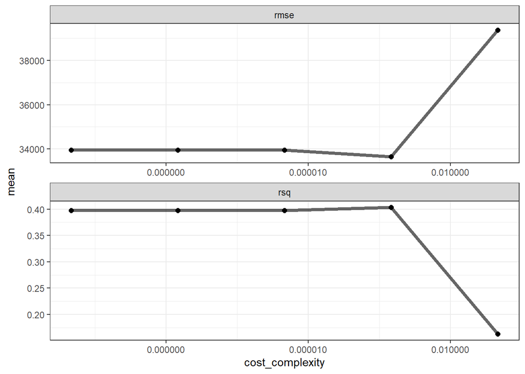

```r
tree_res %>%
  collect_metrics() %>%
  ggplot(aes(cost_complexity, mean)) +
  geom_line(linewidth = 1.5, alpha = 0.6) +
  geom_point(size = 2) +
  facet_wrap(~ .metric, scales = "free", nrow = 2) +
  scale_x_log10(labels = scales::label_number()) +
  scale_color_viridis_d(option = "plasma", begin = .9, end = 0)
```

> - `mtry` (optional) is the number of variables to be randomly sampled per iteration. Default is $\sqrt{k}$ for classification and $\frac{k}{3}$ for regression. Default set to the square root of the number of variables.
> - `tree` (optional) is the number of trees. Default is 500.
> - `min_n` (optional) is the minimum size of any leaf node. The default settings vary by modeling problem. For example, the minimum for regression problems is $n=5$, whereas the minimum for classification is $n=1$.

We could task `tidymodels` to test a large number of automatically selected scenarios. To save on time, we instead specify sensible default hyperparameters: each tree sub-samples $\sqrt{k}$ variables per tree ($mtry = 24$ in this case).[^3]

*An aside: why not tune the Random Forest?* Random Forests are computationally intensive and conducting a grid search can be time consuming. As an initial prototype, the objective is to produce *something* that is as accurate but operational as possible to prove that the concept works. *Show the thing* and prioritize speed. A Random Forest trained even with default hyperparameters generally offers improvements over CART and linear regression. Thus, testing a single hyperparameter set might yield a clear gains over the alternative CART – a good zero-to-one improvement – a version 1 (v1). If we see little or no improvement, then we can assume that a Random Forest could require more exhaustive effort to optimize – a good candidate for a version 2 effort (v2).

```r
rf_mod <-
  rand_forest() %>%
  set_mode('regression') %>%
  set_engine('ranger', importance = "impurity")


rf_wf <-
  workflow() %>%
  add_model(rf_mod) %>%
  add_recipe(tree_recipe)

rf_res <-
  rf_wf %>%
  fit_resamples(folds)

rf_res %>%
  collect_metrics()
```

| .metric | .estimator | mean | n | std_err | .config |
| --- | --- | --- | --- | --- | --- |
| rmse | standard | 3.081335e+04 | 5 | 5.086831e+02 | Preprocessor1_Model1 |
| rsq | standard | 5.080631e-01 | 5 | 9.402701e-03 | Preprocessor1_Model1 |

```r
tree_res %>% show_best('rmse')
```

| cost_complexity | .metric | .estimator | mean | n | std_err | .config |
| --- | --- | --- | --- | --- | --- | --- |
| 5.623413e-04 | rmse | standard | 33652.52 | 5 | 745.5880 | Preprocessor1_Model4 |
| 3.162278e-06 | rmse | standard | 33950.22 | 5 | 857.5155 | Preprocessor1_Model3 |
| 1.000000e-10 | rmse | standard | 33950.65 | 5 | 857.7064 | Preprocessor1_Model1 |
| 1.778279e-08 | rmse | standard | 33950.65 | 5 | 857.7064 | Preprocessor1_Model2 |
| 1.000000e-01 | rmse | standard | 39372.82 | 5 | 809.2163 | Preprocessor1_Model5 |

**Evaluating models**. Compare best RMSE and R2.[^4] The decision is an easy one: lean on the Random Forest.

*Raw accuracy is hard to sell, even if the performance gains are large.*[^5] What is satisfactory for a data scientist might not be for policy makers – there is a need for a policy narrative that maps where an algorithm or program in the normative. There is a need for closure and transparency, especially when decisions are being made.

Whereas CART lends self to producing profiles, Random Forests are a different breed. To begin the unravel the mysteries that the Random Forests has learned, we can rely on variable importance metrics to tell that story. The Random Forest derives the most information from number of hours worked (`wkhp`), followed by years of experience (`exp`) and various levels of education attainment (`schl`). Remember, importance does not show direction of correlation, but rather shows how much the algorithm relies on a variable to split the sample.

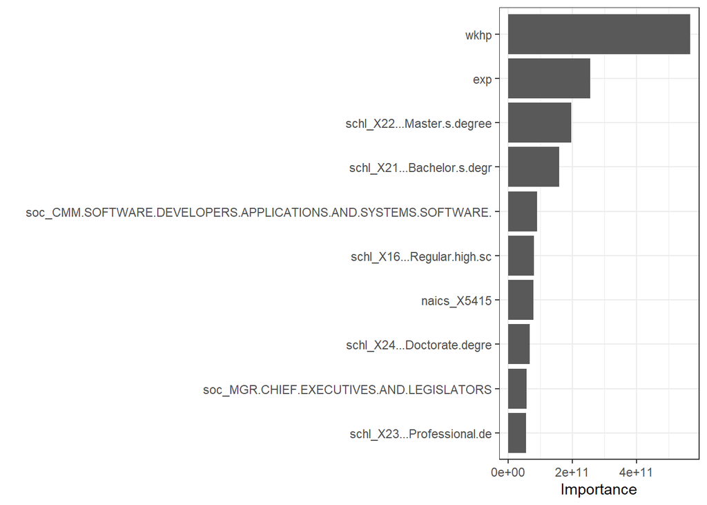

**Producing predictions**. Random Forests produce predictions $\hat{y}_i$ like any other algorithm by making use of the `predict` function. Below, the trained model scores the `test` set.

```r
placehold_rf %>% augment(test) %>%
  select(wage, .pred)
```

| wage | .pred |
| --- | --- |
| 15000 | 20125.851 |
| 21100 | 36555.600 |
| 12000 | 31142.578 |
| 20200 | 33580.865 |
| 8000 | 15887.000 |
| 75000 | 39592.296 |
| 23000 | 31712.804 |
| 24000 | 48361.138 |
| 25000 | 46490.309 |
| 43000 | 60331.201 |

[output cut: 2990 more lines]

[^1]: The ACS is a probability sample with sampling weights. To produce population statistics from the data, we need to account for these weights; However, for this use case, we will treat each observation with equal weight.
[^2]: The number of folds could be increased but with greater time cost. As you will see when we begin training the models, the Random Forest will take some time to run. If the number of folds were increased, we not only would obtain more precise model accuracy estimates but the time required also increases. Thus, we select a smaller value for demonstration purposes.
[^3]: As each level of a categorical variable (e.g. `soc`, `naics`, `schl`) is treated as a dummy variable, we test $mtry = 24$.
[^4]: Note that exact results will differ slightly from one user to the other due to the random sampling in cross validation.
[^5]: Contextualized performance gains in terms of dollars and lives saved are a different story, however.